# Assignment Predictive Analysis

Aanish Singla

21 May 2016

## Problem Description:

The goal of this project is to detect mistakes in weight-lifting exercises by using activity recognition techniques. Experiment included recorded users performing the same activity correctly (calsse=A) and with a set of common mistakes (classe=B,C,D and E) with wearable sensors. Participants were asked to perform one set of 10 repetitions of the Unilateral Dumbbell Biceps Curl in five different fashions: exactly according to the specification (Class A), throwing the elbows to the front (Class B), lifting the dumbbell only halfway (Class C), lowering the dumbbell only halfway (Class D) and throwing the hips to the front (Class E).

The variable to be predicted is “classe” variable in the training set. Measurements taken by sensors are used to predict if the exercise was done correctly or not.

Data used in this analysis is from “Velloso, E.; Bulling, A.; Gellersen, H.; Ugulino, W.; Fuks, H. Qualitative Activity Recognition of Weight Lifting Exercises. Proceedings of 4th International Conference in Cooperation with SIGCHI (Augmented Human ’13) . Stuttgart, Germany: ACM SIGCHI, 2013.” paper.

Read more: http://groupware.les.inf.puc-rio.br/har#ixzz49DkwG8S9.

## Data Analysis:

Lets load the training dataset and have a look at it.

```r
getwd()
```

```
## [1] "D:/R Directory/Dumbbell"
```

```r
train <- read.csv("pml-training.csv", header=T, na.strings = c("", "NA", "#DIV/0!"), sep=",")
dim(train)
```

```
## [1] 19622   160
```

Its a huge dataset. Lets look if there are any missing vales/NAs in the data:

```r
sum(colSums(is.na(train)))
```

```
## [1] 1925102
```

There are a lot of missing values. Lets remove the missing values.

```r
train <- train[, colSums(is.na(train)) == 0]
```

Lets also remove the initial columns which don’t have useful data.

```r
dim(train)
```

```
## [1] 19622    60
```

```r
train <- train[,-c(1:7)]
dim(train)
```

```
## [1] 19622    53
```

We are not left with 53 variable out of which classe is the variable that we want to predict.

52 is still a big number. Lets see if there are some variables which are highly correlated.

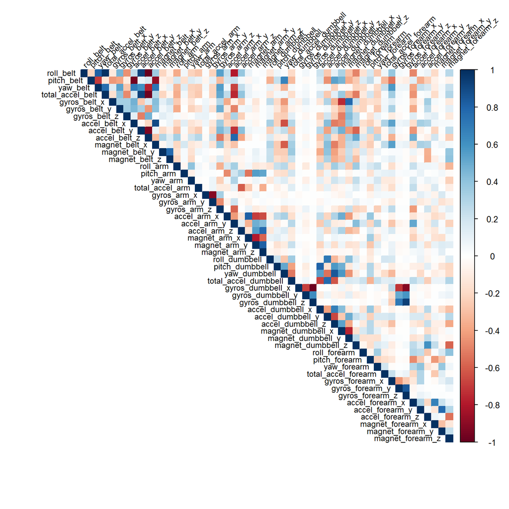

```r
corr <- cor(train[,-53])
corrplot(corr, type="upper", method="color", tl.cex = 0.75, tl.srt = 45, tl.col="black")
```

Dark colors mean high correlation. We can see from the above plot that there are lot of correlated variables. Lets remove the ones which have correlation above 0.6.

```r
select_idx <- findCorrelation(corr, cutoff = 0.6)
length(select_idx)
```

```
## [1] 27
```

## Model Selection:

Before building the model, lets build training and cross validations sets with 75% of data in training and 25% in cross validation.

```r
idx <- createDataPartition(train$class, p=0.75, list=FALSE)

training <- train[idx,]
cv <- train[-idx,]
```

## Tree Based Model:

Lets start with a tree based model to predict classe variable.

```r
set.seed(115)
modtree <- train(classe~., method="rpart", data=training[,c(select_idx,53)])
modtree
```

```
## CART
##
## 14718 samples
##    27 predictor
##     5 classes: 'A', 'B', 'C', 'D', 'E'
##
## No pre-processing
## Resampling: Bootstrapped (25 reps)
## Summary of sample sizes: 14718, 14718, 14718, 14718, 14718, 14718, ...
## Resampling results across tuning parameters:
##
##   cp          Accuracy   Kappa
##   0.02876673  0.4582929  0.27258490
##   0.08554068  0.4000155  0.17946716
##   0.11364284  0.3477763  0.09714096
##
## Accuracy was used to select the optimal model using  the largest value.
## The final value used for the model was cp = 0.02876673.
```

The accuracy is less than 50%, so this doesn’t seem to a good model.

## LDA Model:

Since this is a classification problem, we can try Linear Discriminant Analysis:

```r
modlda <- train(classe~., method="lda", data=training[,c(select_idx,53)])
modlda
```

```
## Linear Discriminant Analysis
##
## 14718 samples
##    27 predictor
##     5 classes: 'A', 'B', 'C', 'D', 'E'
##
## No pre-processing
## Resampling: Bootstrapped (25 reps)
## Summary of sample sizes: 14718, 14718, 14718, 14718, 14718, 14718, ...
## Resampling results:
##
##   Accuracy   Kappa
##   0.5893749  0.4760525
##
##
```

The accuracy is about 58%, but still not great.

## Randon Forest:

Lets try Random Forest

```r
modrf <- randomForest(classe~., data=training[,c(select_idx,53)])
modrf
```

```
##
## Call:
##  randomForest(formula = classe ~ ., data = training[, c(select_idx,      53)])
##                Type of random forest: classification
##                      Number of trees: 500
## No. of variables tried at each split: 5
##
##         OOB estimate of  error rate: 0.84%
## Confusion matrix:
##      A    B    C    D    E class.error
## A 4177    3    2    2    1 0.001911589
## B   23 2804   21    0    0 0.015449438
## C    1   18 2545    3    0 0.008570316
## D    1    0   35 2376    0 0.014925373
## E    0    2    4    7 2693 0.004804139
```

## Estimating Out of sample Error:

Lets use the cross validatoion set to to estimate the out of sample error using random forest.

```r
pred <- predict(modrf, cv[,c(select_idx,53)])
confusionMatrix(cv$classe, pred)
```

```
## Confusion Matrix and Statistics
##
##           Reference
## Prediction    A    B    C    D    E
##          A 1391    1    3    0    0
##          B    2  942    5    0    0
##          C    0    4  850    1    0
##          D    0    0   16  787    1
##          E    0    1    0    1  899
##
## Overall Statistics
##
##                Accuracy : 0.9929
##                  95% CI : (0.9901, 0.995)
##     No Information Rate : 0.2841
##     P-Value [Acc > NIR] : < 2.2e-16
##
##                   Kappa : 0.991
##  Mcnemar's Test P-Value : NA
##
## Statistics by Class:
##
##                      Class: A Class: B Class: C Class: D Class: E
## Sensitivity            0.9986   0.9937   0.9725   0.9975   0.9989
## Specificity            0.9989   0.9982   0.9988   0.9959   0.9995
## Pos Pred Value         0.9971   0.9926   0.9942   0.9789   0.9978
## Neg Pred Value         0.9994   0.9985   0.9941   0.9995   0.9998
## Prevalence             0.2841   0.1933   0.1782   0.1609   0.1835
## Detection Rate         0.2836   0.1921   0.1733   0.1605   0.1833
## Detection Prevalence   0.2845   0.1935   0.1743   0.1639   0.1837
## Balanced Accuracy      0.9987   0.9960   0.9856   0.9967   0.9992
```

## Conclusion: We were successfully able to detect mistakes in weight-lifting exercises by using activity recognition techniques with random forest model with an estimated error rate of less than 1.5 witjh 95% confidence.